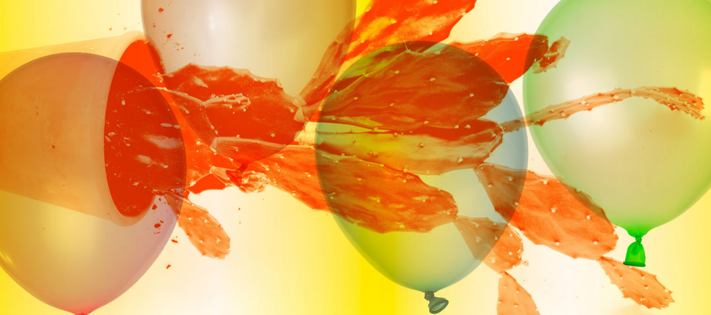

© Collage: Cyan©

# Ek | Ekman

Choreographien von Mats Ek und Alexander Ekman

Informationen zum Werk

105 Minuten inkl. 1 Pause

- Premiere

  16

  19:30

  Feb

  Do

  Feb

  Sa

  Feb

  Di

  12

  16:00

  Mär

  So

  Mär

  So

  22

  19:30

  Mär

  Mi

A SORT OF…  
Choreographie von Mats Ek  
Musik von Henryk M. Górecki  
Mats Ek gehört zu den führenden Choreographen-Persönlichkeiten des 20. Jahrhunderts. Mit seiner radikalen Neuinterpretation des Ballettklassikers GISELLE für das Cullberg Ballet erregte er 1982 weitreichende internationale Aufmerksamkeit, da zuvor niemand den ursprünglichen choreographischen Text und die Form des Librettos zu ändern gewagt hatte. Kritiker und Publikum erkannten in dieser Fassung den Beginn einer neuen Epoche des Bühnentanzes.  
»Meine Choreographien sind mit einem Subtext unterlegt: wenn man sie tanzt, muss man mit der Bewegung bestimmte Bilder und Gefühle verbinden. Ohne diese sehen die Bewegungen einfach nur merkwürdig und fremd aus. Der Fokus muss immer klar sein: bei einem Solo liegt er im Inneren der Person, bei mehreren Tänzern im Bezug auf das Gegenüber«, so beschreibt er selbst die Haltung, die zur Interpretation seiner Choreographien erforderlich ist. Mit den Tänzerinnen und Tänzern des Staatsballetts Berlin erarbeitet er nun sein Stück A SORT OF…, uraufgeführt 1997 beim Nederlands Dans Theater.  
CACTI  
Choreographie von Alexander Ekman  
Musik von Joseph Haydn, Ludwig van Beethoven und Franz Schubert  
Als scharfer Beobachter richtet der Choreograph Alexander Ekman seinen Blick auf die zeitgenössische Tanzszene, die er bestens kennt. Sein Ballett CACTI von 2010 ist eine fröhliche Parodie auf die Exzesse dieser Kunstform und eine liebevoll pointierte Dekonstruktion der Affektiertheit dieser kreativen Szene. 27 Tänzer:innen stehen, scheinbar gefangen, auf Holz-Quadraten. Während ein Streichquartett spielt und Sprechaufnahmen augenzwinkernd vom Geschehen erzählen, versuchen sie, ihren unsichtbaren Gefängnissen zu entkommen. Schließlich — und das ist das Wichtigste — erwerben sie jeweils einen Kaktus. Aber was bedeutet das alles?  
»In diesem Werk geht es darum, wie wir Kunst beobachten und wie wir oft das Bedürfnis verspüren, Kunst zu analysieren und zu verstehen. Ich glaube, dass es keinen richtigen Weg gibt und jeder Kunst so interpretieren und erleben kann, wie er möchte. Womöglich ist es nur ein Gefühl, das man nicht erklären kann, womöglich aber auch eine sehr offensichtliche Botschaft.« Mit seinem Werk CACTI hat der schwedische Choreograph offenbar einen Nerv getroffen, denn das Werk wurde inzwischen von zwanzig Tanzcompagnien weltweit aufgeführt.